# Final Project

Sean Letzer

## Abstract

- Islanders can possibly feel more happy when they have higher serotonin levels in the brain. This study tested whether or not listening to classical music increases serotonin levels. There was not enough concluding evidence in support of there being an increased level of serotonin due to listening to classical music. There seems to be no difference in serotonin levels.

## Introduction

- This experiment was conducted with the goal: See if playing classical music for an interval of 20 minutes, made any effect in the change of serotonin levels in the Islanders brains.
- The findings of this experiment would be positively consequential in that, if classical music increases serotonin in the brain, we would be able to increase potential happiness of the Islanders by incorporating classical music in more facets of life. For example, if classical music increased seronotonin (which has been found to relate to feelings of happiness) in the coffee shops or restaurants on the Island we could play classical music, and possibly lighten the moods of the Islaners!
- To generalize to all Islanders, this experiment had to select a control group/treament group that was completely random in age, gender, and location on the island as serotonin levels can be affected by all three variables.

## Methods

- To pick the samples for each treament group, I first used a random seed number generator in R, and computed the modulus of that number by 39 (since thats how many villages there were on the Island). After getting a random village, I would enter that village and then recreate the random number by the process described earlier, but I would modulo it by the number of houses within the village. I would do this again to pick the participant. After selecting 30 random participants, I performed the same action to create a control group of 15 participants, and a treatment group of 15 participants.
- The statisical method employed in this randomized experiment was a two sample t-test. I had calculated the difference in means between the two numerical groups, and subtracted it from the null hypothesis (mu of 0) and divided it by the standard error. This value was then used in conjunction with the degrees of freedom (14) to find the p-value used in inference testing. From this t value I also genereated a confidence interval to estimate the population mean, useful in inference testing as well.

## Results

- The summary statistics for the Control group:

```
##    Min. 1st Qu.  Median    Mean 3rd Qu.    Max.
##   165.0   191.5   199.0   205.5   218.5   241.0
```

- The summary statistics for the Treament group:

[output not shown]

- To get an idea of the variability of the data I have provided a side-by-side box-whisker plot.

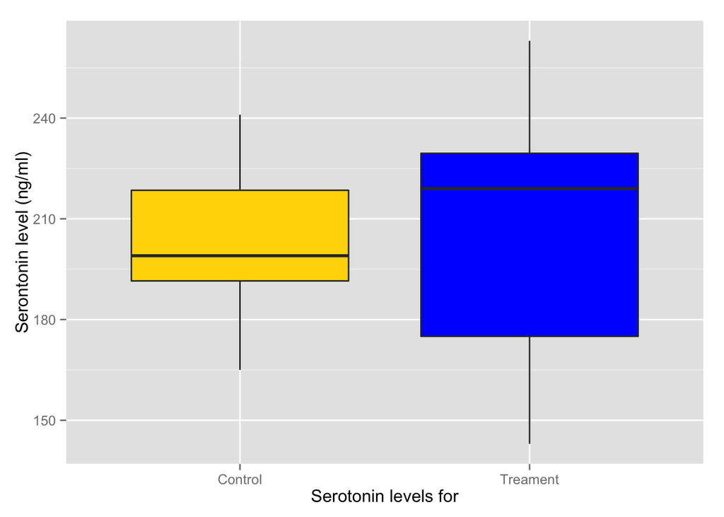

- From this box plot its evident that the treatment has much more variability in its data due to its fairly large IQR range. The two medians differ by a fairly large amount, which raises questions about the correlation of the data.
- To find out more about the relationship of the data, I have provided a scatterplot of the control data versus treatment data, with a regression curve to fit the data.

[output not shown]

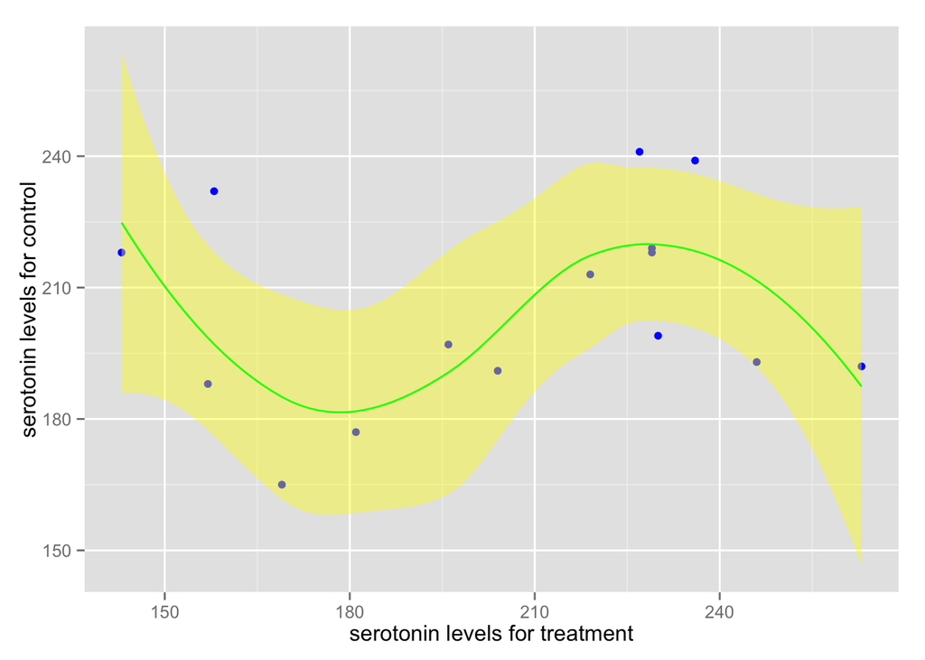